# Lab 3: Data Wrangling & Data Viz pt. 1

Your group member names here (include last names!)

September 11

## Motivation: What’s going on in this graph?

- Click on the link to the New York Times graph below.

https://www.nytimes.com/2019/02/07/learning/whats-going-on-in-this-graph-feb-13-2019.html

- Answer the following questions. The questions are intended to build on one another, so try to answer them in order!

**1. What do you notice?**

**2. What do you wonder?**

**3. What are you curious about that comes from what you notice in the graph?**

**4. Write a catchy headline that captures the graph’s main idea. If your headline makes a claim, tell us what you noticed that supports your claim.**

## Data for Today’s Lab

The SIPRI (Stockholm International Peace Research Institute) Military Expenditure Database is an open source dataset with contains consistent time series on the military spending of countries for the period 1949–2018. The database is updated annually, which may include updates to data for any of the years included in the database.

Military expenditure in local currency at current prices is presented according to both the financial year of each country and according to calendar year, calculated on the assumption that, where financial years do not correspond to calendar years, spending is distributed evenly through the year. Figures in constant (2017) and current US $, as a share of GDP and per capita are presented according to calendar year.

The availability of data varies considerably by country, but for a majority of countries that were independent at the time, data is available from at least the late 1950s. Estimates for regional military expenditure have been extended backwards depending on availability of data for countries in the region, but no estimates for total world military expenditure are available before 1988 due to the lack of data for the Soviet Union.

SIPRI military expenditure data is based on open sources only.

**5. Use the code below to load the data into your work space and inspect it to answer the following questions:**

- **How many observations (rows) do the data have? How many variables (columns) do the data have?**
- **Last week the variables that contained numbers were coded as doubles/numeric. Why do you believe all of the variables are coded as characters?**

```r
# The dataset is an excel file, so we need to use the read_xlsx function
# which lives in the readxl package

library(readxl) # loading in readxl package
library(tidyverse) # loading in tidyverse package
# contains dpylr, tidyr, and ggplot

military <- read_xlsx("data/gov_spending_per_capita.xlsx")

glimpse(military)
```

```
## Observations: 190
## Variables: 33
## $ Country <chr> "Africa", "North Africa", "Algeria", "Libya", "Morocco...
## $ Notes   <chr> NA, NA, "1", "‡ ¶ 2", "3", NA, NA, "‖ 4", NA, NA, "†",...
## $ `1988`  <chr> NA, NA, "41.82793891872582", ". .", "38.28044550855261...
## $ `1989`  <chr> NA, NA, "33.823423839344265", ". .", "40.5612932719788...
## $ `1990`  <chr> NA, NA, "34.897203916409538", ". .", "42.9966897562762...
## $ `1991`  <chr> NA, NA, "21.280826285135216", ". .", "45.3270697221078...
## $ `1992`  <chr> NA, NA, "38.751260074101708", ". .", "47.6330123751497...
## $ `1993`  <chr> NA, NA, "45.954767898967035", ". .", "47.7099761052205...
## $ `1994`  <chr> NA, NA, "47.066488253757583", ". .", "51.1961435980644...
## $ `1995`  <chr> NA, NA, "42.715280322181606", ". .", "53.1075301862266...
## $ `1996`  <chr> NA, NA, "49.383241430113934", ". .", "52.6983580529197...
## $ `1997`  <chr> NA, NA, "58.634346628200056", "244.65995774063362", "5...
## $ `1998`  <chr> NA, NA, "62.993767629190501", "277.85991772636032", "5...
```

[output cut: 20 more lines]

**6. What are the four ways that missing or unavailable values were coded in this dataset?**

Let’s recode all of these missing values into NA responses.

```r
military_clean <- military %>%
                    select(-Country, -Notes) %>%
                    # removes the Country and Notes variables from the dataset
                    mutate_if(is.character, as.numeric) %>%
                    # changes the variables that are characters to numeric
                    mutate(Country = military$Country) %>%
                    # adds the Country variable back in
                    select(Country, everything())
                    # reorders the variables so Country is first
```

**7. Now, write two questions you group is interested in answering with these data?**

- **Question 1:**
- **Question 2:**

A few questions that the NY Times graph stirred up for me were:

- How has the distribution of military spending has looked across the years?
- Has the US’ military expenditures always been at the top of the world?

## Data Organization

The comparison I am interested in looking at the military expenditures of different countries across every year in the data. Something like this:

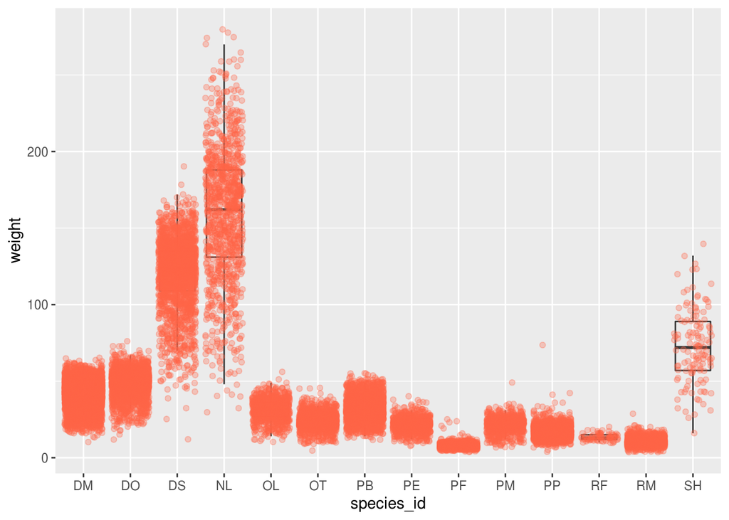

Generally, we will consider data to be “tidy” if they follow three basic rules:  
1. Each variable has its own column.  
2. Each observation has its own row.  
3. Each value has its own cell.

## Wide to Long Using `tidyr`

To tidy a dataset like this, we need to gather those columns into a new pair of variables. To do this process we need three parameters:

- The set of columns that represent values, not variables. In these data, those are all the columns from 1988 to 2018.
- The name of the variable whose values form the column names. This is called the *key*, and for these data it is `year`.
- The name of the variable whose values are spread over the cells. This I call the *value*, and for these data it’s the `spending`.

All of these pieces together form the arguments to the `gather()` function.

```r
long_data <- military_clean %>%
              gather(-Country, key = "year", value = "spending")
```

**8. Inspect the gathered dataset! What does it look like? Does it look like what you were expecting?**